# Covid Analysis Package

Gerard Garvan, Dan Golden, Vineeth Kurnala

12/13/2020

## Introduction

This report will cover the three primary functions of this package:

- Retrieving COVID data from the CDC
  - pull_covid_data()
- Plotting historic cases and deaths
  - covid_cases_graph()
  - covid_deaths_graph()
- Modeling future cases or deaths
  - covid_ts_forecast()

## Centers for Disease Control and Prevention Data

The Centers for Disease Control (CDC) makes COVID-19 case and death data available to the public. This data can be accessed via a URL that allows subsets of the large dataset to be downloaded. This service is provided by an application programming interface (API). The API allows public access to COVID-19 data in either CSV or JSON formats.

A CSV is a standard format for storing data that uses comma separated values. Data fields are separated by commas thus identifying unique entries. JSON is a newer data format that is more flexible than CSV and can handle less structured data. Data for this project will be retrieved in CSV format, and the CSV will be read into an R dataframe for use in analysis.

The CDC data can be retrieved using three different methods. The first method is simply to download an entire CSV that contains all available data. The second method uses simple additions to the base URL that allow for a minimal amount of data subsetting. The third method, which is the method focused on in this report, is the use of query language within the URL to subset data.

The API allowing access to CDC COVID-19 data is build using Socrata. The Socrata site includes the following definition of its service, “The Socrata Open Data API allows you to programmatically access a wealth of open data resources from governments, non-profits, and NGOs around the world.”

Rather than downloading an entire dataset, or applying minimal subsetting, Socrata allows richer subsetting of COVID-19 data directly from the download URL. For example specific dataset fields can be selected, beginning and ending time periods can be defined, and data can be filtered to selected states.

For this project a function was created that can dynamically generate a Socrata compliant URL to query data from the CDC API endpoint. The function generates a URL, retreives COVID-19 data from the URL and formats date fields as dates, and boolean fields as TRUE/FALSE.

Socrata URLs use Socrata Query Language (SoQL) which is extremely similar to Structured Query Language (SQL), an ANSI and ISO industry standard. The primary SoQL commands used to query and filter COVID data are:

- query: allows multiple SoQL commands to be run together
- select: subset columns from the available fields
- where: subset rows from the available data
- limit: specify a maximum amount of data to retrieve

Additional details related to SoQL can be obtained here: https://dev.socrata.com/docs/queries/

### CDC COVID DATA DESCRIPTION

| Field | Datatype | Description |
| --- | --- | --- |
| submission_date | timestamp | Date and time record submited |
| state | text | State where record applies |
| tot_cases | number | Total number of cases |
| conf_cases | number | Total confirmed cases |
| prob_cases | number | Total probable cases |
| new_case | number | Number of new cases |
| pnew_case | number | Number of new probable cases |
| tot_death | number | Total number of deaths |
| conf_death | number | Total number of confirmed deaths |
| prob_death | number | Total number of probable deaths |
| new_death | number | Number of new deaths |
| pnew_death | number | Number of new probable deaths |

Source: United States COVID-19 Cases and Deaths by State over Time https://dev.socrata.com/foundry/data.cdc.gov/9mfq-cb36

## Supplemental Datasets

Three additional datasets are included in the package. All three datasets were obtained from publicly accessible government sites. The datasets are included to support additional analysis and data aggregate to better understand the impact of COVID are various populations.

- SAHIE Insurance Data
  - Census Bureau Description: The U.S. Census Bureau’s Small Area Health Insurance Estimates program produces the only source of data for single-year estimates of health insurance coverage status for all counties in the U.S. by selected economic and demographic characteristics.
  - https://www.census.gov/data/datasets/time-series/demo/sahie/estimates-acs.html
- Demographic Data (Race and Ethnicity)
  - Description: Data from the American Community Survey (ACS) which contains race and ethnicity population data by state. Data is also available at the county level but was included only at the state level to parity match COVID-19 data.
  - https://covid19.census.gov/datasets/race-and-ethnicity-states
- Demographic Data (Age and Sex)
  - Description: Data from the American Community Survey (ACS) which contains age and sex population data by state. Data is also available at the county level but was included only at the state level to parity match COVID-19 data.
  - 2https://covid19.census.gov/datasets/population-by-age-and-sex-states

## Retrieve Data

```r
# Example using dates
pull_covid_data(start_date="2020-06-01", end_date="2020-07-01", limit=5)
```

```
##   submission_date state tot_cases conf_cases prob_cases new_case pnew_case
## 1      2020-06-01    AK       467         NA         NA        7         0
## 2      2020-06-01    AL     18438      18150        288      193        -1
## 3      2020-06-01    AR      7443         NA         NA      190         0
## 4      2020-06-01    AZ     20123      20123          0      187         0
## 5      2020-06-01    CA    113006         NA         NA     2423         0
##   tot_death conf_death prob_death new_death pnew_death
## 1        10         NA         NA         0          0
## 2       646        644          2        14          0
## 3       133         NA         NA         0          0
## 4       917        917          0        11          0
## 5      4251         NA         NA        38          0
```

```r
# Example using dates and states
pull_covid_data(start_date="2020-06-01", end_date="2020-07-01", states=c("FL", "GA", "NY"), limit=5)
```

```
##   submission_date state tot_cases conf_cases prob_cases new_case pnew_case
## 1      2020-06-01    FL     55415         NA         NA      651         0
## 2      2020-06-01    GA     46501      46470         31      889         2
## 3      2020-06-01    NY    167947         NA         NA      480         0
## 4      2020-06-02    FL     56001         NA         NA      586         0
## 5      2020-06-02    GA     47079      47048         31      578         0
##   tot_death conf_death prob_death new_death pnew_death
## 1      2460         NA         NA         9          0
## 2      2074       2074          0        22          0
## 3      8159         NA         NA        29          0
## 4      2530         NA         NA        70          0
## 5      2102       2102          0        28          0
```

```r
# Example using dates and states and fields
pull_covid_data(start_date="2020-06-01", end_date="2020-07-01",
                states=c("FL", "GA", "NY"),
                fields=c("submission_date", "state", "tot_cases", "tot_death"), limit=10)
```

```
##    submission_date state tot_cases tot_death
## 1       2020-06-01    FL     55415      2460
## 2       2020-06-01    GA     46501      2074
## 3       2020-06-01    NY    167947      8159
## 4       2020-06-02    FL     56001      2530
## 5       2020-06-02    GA     47079      2102
## 6       2020-06-02    NY    168663      8198
## 7       2020-06-03    FL     57293      2566
## 8       2020-06-03    GA     47802      2123
## 9       2020-06-03    NY    169213      8230
## 10      2020-06-04    FL     58701      2607
```

## Plots

Historic COVID cases can be plotted using the function covid_cases_graph.

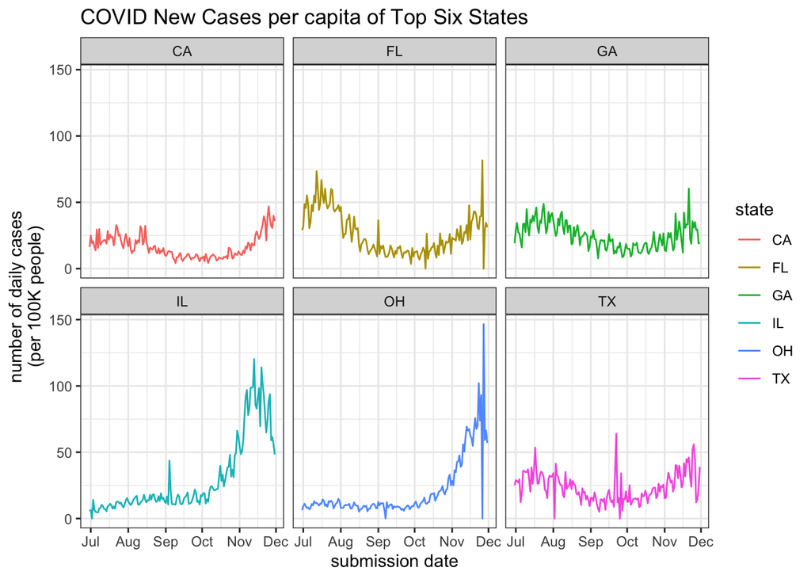

```r
covid_cases_graph("2020-06-30", "2020-11-30",  per100k = TRUE)
```

Historic COVID deaths can be plotted using the function covid_deaths_graph.

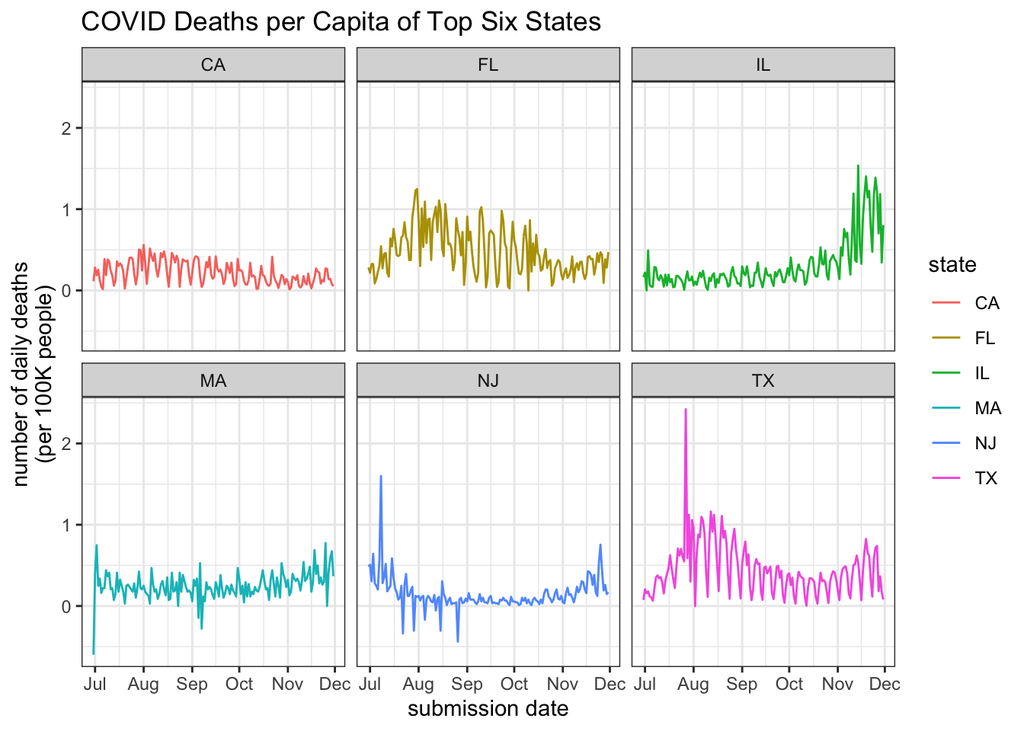

```r
covid_deaths_graph("2020-06-30", "2020-11-30",  per100k = TRUE)
```

## Time Series Forecasting

The analysis of data indexed by equally spaced increments of time to identify patterns and predict values from these patterns is referred to as Time Series Forecasting. The motivation behind pursuing time series forecasting is to obtain an understanding of observed data and fit a model to forecast or monitor future possibilities. CDC is responding to a pandemic of coronavirus disease 2019 (COVID-19) caused by a new coronavirus, SARS-CoV-2, that is spreading from person to person. CDC works with many partners to obtain weekly forecasts based on statistical models that aim to predict

- National and state numbers of new and total COVID-19 deaths per week for the next 4 weeks.
- National and state numbers of new COVID-19 hospitalizations per day for the next 4 weeks.
- National, state, and county numbers of new COVID-19 cases per week for the next 4 weeks.

Forecasts of deaths, hospitalizations, and cases will help inform public health decision making by projecting the likely impact of the COVID-19 pandemic in coming weeks.

In our function `covid_ts_forecast` we implemented time series forecasting to predict new cases or new deaths for the next 100 days across entire USA or by state selection or by regions in USA using 4 different models. All these models use default values in their arguments.

- **Exponential smoothing state space model:** Exponential smoothing is a family of very successful forecasting methods which are based on the key property that forecasts are weighted combinations of past observations. Our model selection is automatically done using `model = "ZZZ"` by default in the ets function. First letter represents error type, second letter represents trend type and third letter represents season type. For more information please refer to the `ets` function documentation of the `forecast` package. https://www.rdocumentation.org/packages/forecast/versions/8.13/topics/ets
- **BATS model (Exponential smoothing state space model with Box-Cox transformation, ARMA errors, Trend and Seasonal components):** A seasonal pattern occurs when a time series is affected by seasonal factors such as the time of the year or the day of the week. Seasonality is induced partly by various factors. Particularly during a pandemic it is very complicated to identify the factors affecting the seasonality. In our model we are not considering any external factors other than the topic of forecast. However seasonality is considered in the BATS model based on either new cases or new deaths. $ARMA(p,q)$ refers to the model with p autoregressive terms and q moving-average terms. This model contains the $AR(p)$ and $MA(q)$ models. The $ARMA(p,q)$ errors are generally assumed to be i.i.d. sampled from a normal distribution with zero mean: $\epsilon_{t}$ ~ $N(0,\sigma^2)$ where $\sigma^2$ is the variance. The Akaike Information Critera (AIC) is a widely used measure of a statistical model. It basically quantifies
  - the goodness of fit, and
  - the simplicity/parsimony, of the model into a single statistic.

  When comparing two models, the one with the lower AIC is generally “better”. In our model we used default parameters such as whether to Box-Cox transformation or include a trend based on the AIC. The best fit is selected automatically by AIC. Our function uses `bats` function from the `forecast` package. For further insights on `bats` function please refer to https://www.rdocumentation.org/packages/forecast/versions/8.13/topics/bats
- **TBATS model (Trigonometric Seasonal Exponential smoothing state space model with Box-Cox transformation, ARMA errors, Trend and Seasonal components):** TBATS is an extension to BATS model that can handle multiple seasonalities. Each seasonality is modeled by a trigonometric representation based on Fourier series. One major advantage of this approach is that it requires only 2 seed states regardless of the length of period. Another advantage is the ability to model seasonal effects of non-integer lengths. For example, given a series of daily observations, one can model leap years with a season of length 365.25. Under the hood TBATS will consider various alternatives and fit quite a few models and select the best fit. It will consider models:
  - with Box-Cox transformation and without it.
  - with and without Trend
  - with and without Trend Damping
  - with and without ARMA(p,q) process used to model residuals non-seasonal model
  - various amounts of harmonics used to model seasonal effects

  The final model will be chosen using AIC. In particular auto ARMA is used to decide if residuals need modeling and what p and q values are suitable. In our function, we used `tbats` R function from `forecast` package with default argument values for selecting the best model. For further information please refer to https://www.rdocumentation.org/packages/forecast/versions/8.4/topics/tbats
- **ARIMA (Autoregressive Integrated Moving Average model):** Our package uses `auto.arima` function from the `forecast` package. ARIMA model is a generalization of ARMA model described above in the BATS model section. ARIMA applies an initial differencing step in the integrated part of the model to handle non-stationarity in the mean of the trend. There are seasonal and non-seasonal ARIMA models. For simplicity, our function assumes seasonality with a default option `seasonal=TRUE` in the `auto.arima` function. Non-seasonal ARIMA models eliminate seasonal component by applying seasonal-differencing. Seasonal-differencing is a form of additive seasonal adjustment: the “index” which is subtracted from each value of the time series is simply the value that was observed in the same season one time period earlier.

  This method has 3 variables to count for.
  - P = Periods to lag for eg: (if P= 3 then we will use the three previous periods of our time series in the autoregressive portion of the calculation) P helps adjust the line that is being fitted to forecast the series.
  - D = In an ARIMA model we transform a time series into stationary one(series without trend or seasonality) using differencing. D refers to the number of differencing transformations required by the time series to get stationary. Stationary time series is when the mean and variance are constant over time. It is easier to predict when the series is stationary.
  - Q = This variable denotes the lag of the error component, where error component is a part of the time series not explained by trend or seasonality

  All 3 variables in our model are automatically selected based on a unit root test from the tests (KPSS, Augmented Dickey-Fuller (ADF), Phillips-Perron (PP)) using the argument `test = c("kpss","adf","pp")`. For further information on these tests please refer to `ndiffs` function of the `forecast` package. For information on `auto.arima` function please refer to https://www.rdocumentation.org/packages/forecast/versions/8.13/topics/auto.arima

### Examples

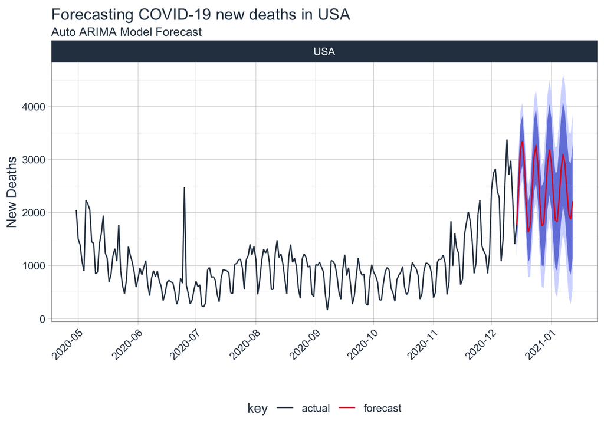

```r
covid_ts_forecast(start_date='2020-04-30', fvar="new_death", model=c("auto.arima"), pred.days = 30)
```

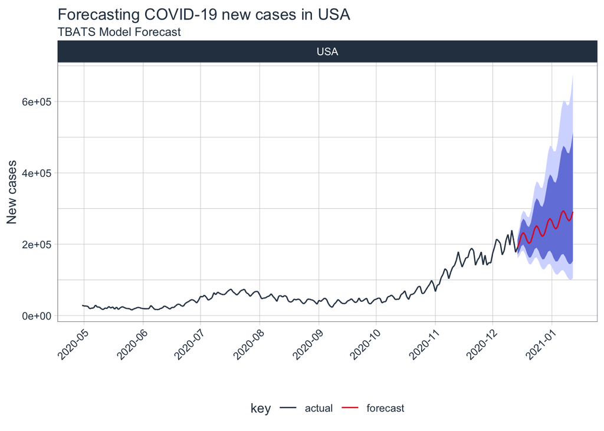

```r
covid_ts_forecast(start_date='2020-04-30', fvar="new_case", model=c("tbats"), pred.days = 30)
```

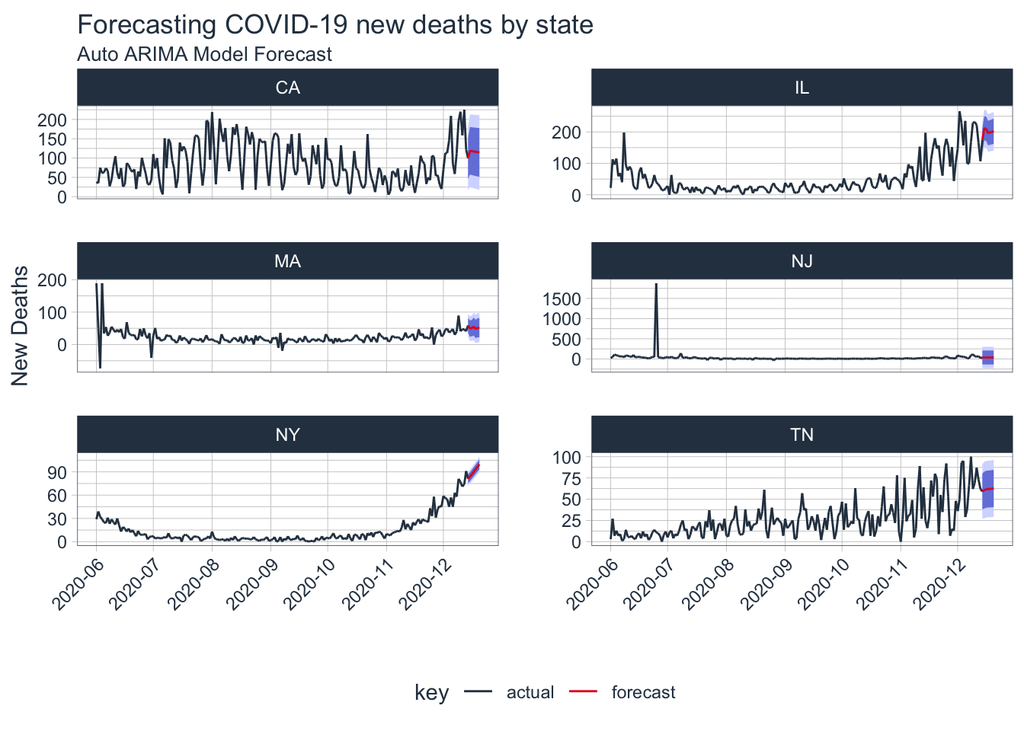

```r
covid_ts_forecast(start_date='2020-06-01', fvar="new_death", state.filter=c("MA","CA","NY","NJ","IL","TN"), model=c("auto.arima"), pred.days = 7)
```

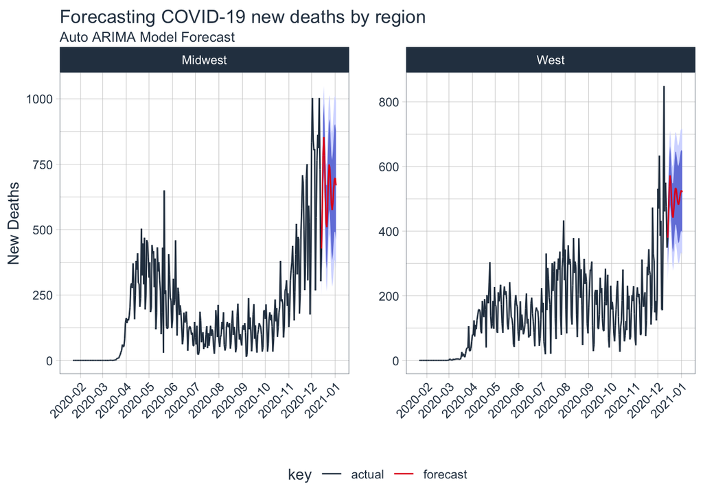

```r
covid_ts_forecast(fvar="new_death",region.filter=c("Midwest","West"),pred.days=20)
```

## Conclusion

This package provides easy access to the most recent data from the CDC, and provides analysis surrounding COVID cases and deaths. This package is meant to be a tool for COVID researchers to use to obtain data, and to understand and predict COVID trends.

## Future Considerations

This package is hosted on Github and thus allows for collaboration among other COVID researchers. The following are additional features that may be included in the package in the future:

- Incorporate additional supplemental datasets
- Include functionality to automatically update supplemental datasets
- Expand the capabilities of historic data plots
- Include additional historic data plots
- Include simulation capabilities for COVID time series modeling
- **Selection of forecasting model parameters**: Current function `covid_ts_forecast` uses all default arguments in the forecasting models. In the future, some flexibility can be added to choose the model parameters such as choosing a seasonal test, stepwise/non-stepwise selection, stationarity, information criterion to be used, choosing a list of ARIMA models, selection of type of unit root test, allowing drift terms, choosing number of cores for parallel processing, allowing backward compatibility, etc.
- **Multivariate timeseries**: Our current function `covid_ts_forecast` uses univariate time series. Forecasting new cases, deaths or hospitalizations during a pandemic requires consideration of various factors that affect the virus spread. This allows to predict the future cases in an efficient manner. An extension to this could be implementation of multivariate time series which considers the dependency of a variable not only on its past values but has some dependency on other variables such as economic/social status, living conditions, comorbidities, vaccine administration, age/race/gender groups, usage of masks, social distancing etc.